# Mood & Climate

Conor Sheehan  
5/16/2018

## Studying Mood and Climate

This tutorial is meant to act as a walkthrough for fundamental Data Science practices, while discovering new insights on the relationship between mood within different climates within the United States. Before we really dive into the code portion, I'm going to layout exactly what we're studying in this tutorial.

#### Mood

Since there are many ways to think about Mood I'm going to break it into three main categories: Personal Well-Being, Social/Communal Well-Being, and Financial well-being. Personal well-being is the overall emotional, mental and physical wellness that people have. While, communal wellness is based on the strength of social ties as well as the time that people spend together. Financial well-being is the overall quality of career satisfaction and income to support a comfortable lifestlye. All three kinds of well being are essential for the balance of a fulfilled life.

#### Climate

Climate is the overall trends of weather in a region over a long period of time. Climate is created through multiple variables creating distinct patterns over time such as longitude, latitude, terrain, altitude, and nearby bodies of water. Here's a link to NASA's page on climate:

https://www.nasa.gov/mission_pages/noaa-n/climate/climate_weather.html

#### My Prediction

Due to all of these variable, climates can be extremely varied and difficult to directly compare. But, in this study we will explore whether there is a correlation between certain types of climates and mood of the population by that area and climate. I hypothesize that there will be a correlation between certain types of climate and moods. We will explore variables including average temperature over different time intervals, precipitation and snowfall in that region.

## Let's get started!

To get started we first need to collect our data. In this tutorial we will focus on scraping data from websites because it's so versatile. We'll start by learning basic R pipelines for scraping data and parsing it into neat data frames. This first example will be scraping a website that contains data on the climate for 100 cities across the United States.

Here's the link:  
https://www.infoplease.com/science-health/weather/climate-100-selected-us-cities

```r
library(tidyr)
library(rvest)
library(magrittr)
library(dplyr)
library(readr)
library(tidyverse)

# Store the URL into a variable we can use later
Climate_URL <- "https://www.infoplease.com/science-health/weather/climate-100-selected-us-cities"


# Here is our first major pipeline for scraping data off websites
climate_table <- Climate_URL %>%
  read_html() %>%
  html_node("table") %>% #This line acts as a css selector to locate the table in the web page
  html_table(fill = TRUE) %>%
  set_colnames(c("City","Avg_Temp_January","Avg_Temp_April","Avg_Temp_July","Avg_Temp_October",
                 "Precipitation_inches", "Precipitation_days", "Snowfall", "Observed_Days")) %>%
  as_data_frame ## Converting to easy to use R data frame


Climate_table_cleaned <- climate_table[-c(1, 2),]

Climate_table_cleaned$Avg_Temp_January = as.numeric(as.character(Climate_table_cleaned$Avg_Temp_January))
Climate_table_cleaned$Avg_Temp_April = as.numeric(as.character(Climate_table_cleaned$Avg_Temp_April))
Climate_table_cleaned$Avg_Temp_October = as.numeric(as.character(Climate_table_cleaned$Avg_Temp_October))
Climate_table_cleaned$Precipitation_inches = as.numeric(as.character(Climate_table_cleaned$Precipitation_inches))
Climate_table_cleaned$Precipitation_days = as.numeric(as.character(Climate_table_cleaned$Precipitation_days)) # Here's our first table!
Climate_table_cleaned
```

```
## # A tibble: 100 x 9
##    City     Avg_Temp_January Avg_Temp_April Avg_Temp_July Avg_Temp_October
##    <chr>               <dbl>          <dbl> <chr>                    <dbl>
##  1 Albany,…             22.2           46.6 71.1                      49.3
##  2 Albuque…             35.7           55.6 78.5                      57.3
##  3 Anchora…             15.8           36.3 58.4                      34.1
##  4 Ashevil…             35.8           54.1 73.0                      55.2
##  5 Atlanta…             42.7           61.6 80.0                      62.8
##  6 Atlanti…             32.1           50.6 75.3                      55.1
##  7 Austin,…             50.2           68.3 84.2                      70.6
##  8 Baltimo…             32.3           53.2 76.5                      55.4
##  9 Baton R…             50.1           66.6 81.7                      68.1
## 10 Billing…             24.0           46.1 72.0                      48.1
## # ... with 90 more rows, and 4 more variables: Precipitation_inches <dbl>,
## #   Precipitation_days <dbl>, Snowfall <chr>, Observed_Days <chr>
```

## Success! Now, let's get data on Mood across Cities

Excellent, now that we collected data on the climate we will also need to also gather data on mood across different cities in the United States to unite these data sets for analysis. I found an interesting article on WalletHub that collected cumulative metrics and calculate overall happiness in different cities. They rate happiness off of emotional well-being, income, and communal well-being to calculate an overall score.

Here's the link: https://wallethub.com/edu/happiest-places-to-live/32619/

Now, that we are clear on our data, let's scrape this site as well for their happiness metrics.

```r
library(tidyr)
library(rvest)
library(magrittr)
library(dplyr)
library(readr)
library(tidyverse)

# Store the URL into a variable we can use later
Mood_URL <- "https://wallethub.com/edu/happiest-places-to-live/32619/"


# Here is our second major pipeline for scraping data off websites
Mood_table_cleaned <- Mood_URL %>%
  read_html() %>%
  html_node("table") %>% #This line acts as a css selector to locate the table in the web page
  html_table(fill = TRUE) %>%
  set_colnames(c("OverallRank","City","Total_Score","Emotional_WB_Rank","Income_WB_Rank", "Communal_WB_Rank")) %>%
  as_data_frame ## Converting to easy to use R data frame

Mood_table_cleaned
```

```
## # A tibble: 182 x 6
##    OverallRank City            Total_Score Emotional_WB_Ra… Income_WB_Rank
##          <int> <chr>                 <dbl>            <int>          <int>
##  1           1 Fremont, CA            79.9                3              6
##  2           2 Bismarck, ND           78.4                4              1
##  3           3 San Jose, CA           76.4                1              8
##  4           4 Pearl City, HI         75.2                2             57
##  5           5 Plano, TX              73.6                8             17
##  6           6 Fargo, ND              73.5               12              2
##  7           7 Sioux Falls, SD        72.0                7             48
##  8           8 Irvine, CA             71.2               13             33
##  9           9 Huntington Bea…        70.7               16             25
## 10          10 Grand Prairie,…        70.5               29             16
## # ... with 172 more rows, and 1 more variable: Communal_WB_Rank <int>
```

## Now we have our core data to begin analytics. Let's do some categorization and parsing..

But, first we must parse the data, so that we can easily work with both of these two tables to explore my the relationship between Mood and Climate. So, right now we have two different studies from two different sources. Therefore, there will be some incongruency in the way they categorized and display data. For starters, we have data in the form of U.S cities, which is great, but doesn't tell us anything about climate. Also, both studies may have studied durastically different cities, therefore we need a way to unite the data. So, we will break up data into states so that the data is easier to analyze.

```r
library(tidyr)
library(rvest)
library(magrittr)
library(dplyr)
library(readr)
library(tidyverse)

## Let's seperate the City columns of both tables into their respective cities and states.
Regional_Mood_table = separate(data = Mood_table_cleaned, col = City, sep = ",", into = c("City", "State"))
Regional_Mood_table
```

```
## # A tibble: 182 x 7
##    OverallRank City      State Total_Score Emotional_WB_Ra… Income_WB_Rank
##          <int> <chr>     <chr>       <dbl>            <int>          <int>
##  1           1 Fremont   " CA"        79.9                3              6
##  2           2 Bismarck  " ND"        78.4                4              1
##  3           3 San Jose  " CA"        76.4                1              8
##  4           4 Pearl Ci… " HI"        75.2                2             57
##  5           5 Plano     " TX"        73.6                8             17
##  6           6 Fargo     " ND"        73.5               12              2
##  7           7 Sioux Fa… " SD"        72.0                7             48
##  8           8 Irvine    " CA"        71.2               13             33
##  9           9 Huntingt… " CA"        70.7               16             25
## 10          10 Grand Pr… " TX"        70.5               29             16
## # ... with 172 more rows, and 1 more variable: Communal_WB_Rank <int>
```

```r
Regional_Climate_table = separate(data = Climate_table_cleaned, col = City, sep = ",", into = c("City", "State"))
Regional_Climate_table
```

```
## # A tibble: 100 x 10
##    City          State     Avg_Temp_January Avg_Temp_April Avg_Temp_July
##    <chr>         <chr>                <dbl>          <dbl> <chr>
##  1 Albany        " N.Y."               22.2           46.6 71.1
##  2 Albuquerque   " N.M."               35.7           55.6 78.5
##  3 Anchorage     " Alaska"             15.8           36.3 58.4
##  4 Asheville     " N.C."               35.8           54.1 73.0
##  5 Atlanta       " Ga."                42.7           61.6 80.0
##  6 Atlantic City " N.J."               32.1           50.6 75.3
##  7 Austin        " Texas"              50.2           68.3 84.2
##  8 Baltimore     " Md."                32.3           53.2 76.5
##  9 Baton Rouge   " La."                50.1           66.6 81.7
## 10 Billings      " Mont."              24.0           46.1 72.0
## # ... with 90 more rows, and 5 more variables: Avg_Temp_October <dbl>,
## #   Precipitation_inches <dbl>, Precipitation_days <dbl>, Snowfall <chr>,
## #   Observed_Days <chr>
```

```r
# Group Climate table by state
State_Climate_table <- Regional_Climate_table %>% group_by(State) %>%
  summarize(Avg_Temp_April = mean(Avg_Temp_April), Avg_Temp_January = mean(Avg_Temp_January), Avg_Precipitation_inches = mean(Precipitation_inches), Avg_Precipitation_days = mean(Precipitation_days))
State_Climate_table
```

```
## # A tibble: 51 x 5
##    State Avg_Temp_April Avg_Temp_January Avg_Precipitati… Avg_Precipitati…
##    <chr>          <dbl>            <dbl>            <dbl>            <dbl>
##  1 " Al…           63.9             46.4             58.4            115
##  2 " Al…           36.3             10.6             28.2            148
##  3 " Ar…           68.1             53.0             10.2             44.5
##  4 " Ar…           61.4             40.1             50.9            104
##  5 " Ca…           60.3             53.5             15.0             45.6
##  6 " Co…           49.2             27.6             12.4             80.5
##  7 " Co…           48.9             27.8             45.2            124
##  8 " D.…           56.1             34.9             39.4            113
##  9 " De…           52.4             31.5             42.8            117
## 10 " Fl…           71.3             61.4             51.9            120
## # ... with 41 more rows
```

```r
# Group Mood table by state
State_Mood_table <- Regional_Mood_table %>% group_by(State) %>%
  summarize(Emotional_WB_Rank = mean(Emotional_WB_Rank),Communal_WB_Rank = mean(Communal_WB_Rank), Income_WB_Rank = mean(Income_WB_Rank),
            Overall_WB_Rank = (Emotional_WB_Rank+Communal_WB_Rank+Income_WB_Rank)/3)


#Next we need to standardize the state column abbreviations, so that we can join the tables for data analysis.

State_Mood_table$State_std = c("AK","AL","AR","AZ","CA","CO","CT","DC","DE","FL",
                               "GA","HI","IA","IL","ID","IN","KS","KY","LA","MA",
                              "MD","ME","MI","MN","MO","MS","MT","NC","ND","NE",
                              "NH","NJ","NM","NV","NY","OH","OK","OR","PA","RI",
                              "SC","SD","TN", "TX","UT","VA","VT","WA","WI","WV",
                              "WY")
State_Mood_table
```

```
## # A tibble: 51 x 6
##    State Emotional_WB_Rank Communal_WB_Rank Income_WB_Rank Overall_WB_Rank
##    <chr>             <dbl>            <dbl>          <dbl>           <dbl>
##  1 " AK"              72.5            112             29.5            71.3
##  2 " AL"             167               88.0          152             136
##  3 " AR"             178               91.5          132             134
##  4 " AZ"              75.6             80.1           73.7            76.4
##  5 " CA"              53.6             73.3           76.9            67.9
##  6 " CO"              56.0             83.3           69.3            69.6
##  7 " CT"             129              148            156             145
##  8 " DC"              15.0            171             31.0            72.3
##  9 " DE"             129              179            142             150
## 10 " FL"              84.5            119             94.0            99.2
## # ... with 41 more rows, and 1 more variable: State_std <chr>
```

```r
State_Climate_table$State_std = c("AL","AK","AZ","AR","CA","CO","CT","DC","DE","FL",
                               "GA","HI","IA","ID","IL","IN","KS","KY","LA","ME","MA",
                              "MD","MI","MN","MS","MO","MT","NC","ND","NH",
                              "NJ","NM", "NY", "NE","NV","OH","OK","OR","PA","RI",
                              "SC","SD","TN", "TX","UT","VA","VT","WV","WA","WI",
                              "WY")
State_Climate_table
```

```
## # A tibble: 51 x 6
##    State Avg_Temp_April Avg_Temp_January Avg_Precipitati… Avg_Precipitati…
##    <chr>          <dbl>            <dbl>            <dbl>            <dbl>
##  1 " Al…           63.9             46.4             58.4            115
##  2 " Al…           36.3             10.6             28.2            148
##  3 " Ar…           68.1             53.0             10.2             44.5
##  4 " Ar…           61.4             40.1             50.9            104
##  5 " Ca…           60.3             53.5             15.0             45.6
##  6 " Co…           49.2             27.6             12.4             80.5
##  7 " Co…           48.9             27.8             45.2            124
##  8 " D.…           56.1             34.9             39.4            113
##  9 " De…           52.4             31.5             42.8            117
## 10 " Fl…           71.3             61.4             51.9            120
## # ... with 41 more rows, and 1 more variable: State_std <chr>
```

```r
United_Table <- merge(State_Mood_table,State_Climate_table, by = "State_std")

# Now we finally have data that we can run EDA and look for trends in the data
United_Table %>% slice(1:10)
```

```
## # A tibble: 10 x 11
##    State_std State.x Emotional_WB_Rank Communal_WB_Rank Income_WB_Rank
##    <chr>     <chr>               <dbl>            <dbl>          <dbl>
##  1 AK        " AK"                72.5            112             29.5
##  2 AL        " AL"               167               88.0          152
##  3 AR        " AR"               178               91.5          132
##  4 AZ        " AZ"                75.6             80.1           73.7
##  5 CA        " CA"                53.6             73.3           76.9
##  6 CO        " CO"                56.0             83.3           69.3
##  7 CT        " CT"               129              148            156
##  8 DC        " DC"                15.0            171             31.0
##  9 DE        " DE"               129              179            142
## 10 FL        " FL"                84.5            119             94.0
## # ... with 6 more variables: Overall_WB_Rank <dbl>, State.y <chr>,
## #   Avg_Temp_April <dbl>, Avg_Temp_January <dbl>,
## #   Avg_Precipitation_inches <dbl>, Avg_Precipitation_days <dbl>
```

## EDA

#### Overall Well-Being Rank Vs. Average Temperature in January by State (Lower Rank is Higher Well Being)

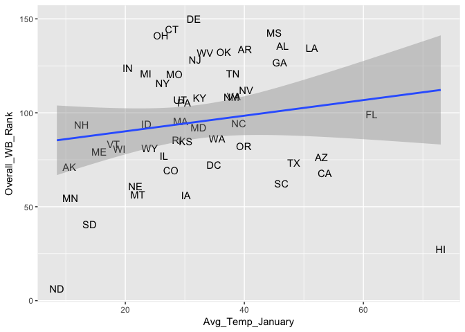

```r
library(ggplot2)


United_Table %>%
  ggplot(aes(x=Avg_Temp_January, y=Overall_WB_Rank, label = State_std)) + geom_text() + geom_smooth(method = lm)
```

#### Linear model summaries of winter temperature vs well-being

```r
library(ggplot2)
library(tidyverse)
library(broom)

# These next to steps are calculating a linear model for average january temperature vs. Overall Well Being.
regr_model <-  lm(United_Table$Avg_Temp_January ~ United_Table$Overall_WB_Rank)
regr_model
```

```
##
## Call:
## lm(formula = United_Table$Avg_Temp_January ~ United_Table$Overall_WB_Rank)
##
## Coefficients:
##                  (Intercept)  United_Table$Overall_WB_Rank
##                     25.51920                       0.07178
```

```r
summary(regr_model)
```

```
##
## Call:
## lm(formula = United_Table$Avg_Temp_January ~ United_Table$Overall_WB_Rank)
##
## Residuals:
##     Min      1Q  Median      3Q     Max
## -20.039  -8.144  -2.862   5.861  45.507
##
## Coefficients:
##                              Estimate Std. Error t value Pr(>|t|)
## (Intercept)                  25.51920    5.87097   4.347 6.96e-05 ***
## United_Table$Overall_WB_Rank  0.07178    0.05849   1.227    0.226
## ---
## Signif. codes:  0 '***' 0.001 '**' 0.01 '*' 0.05 '.' 0.1 ' ' 1
##
## Residual standard error: 13.19 on 49 degrees of freedom
## Multiple R-squared:  0.02982,    Adjusted R-squared:  0.01002
## F-statistic: 1.506 on 1 and 49 DF,  p-value: 0.2256
```

#### Poor Linear Fit

So, we can see through our fit by the adjusted R-Squared value, a linear model only explains about 1% of the variance in the regression fit. Also, our p-value is relatively high and would not match a 5% standard of significance for a linear fit between these two variables.

## Let's try a new way

The stat_smooth function in the ggplot methods is used to predict a best fit model for data that is more complex to analyze.

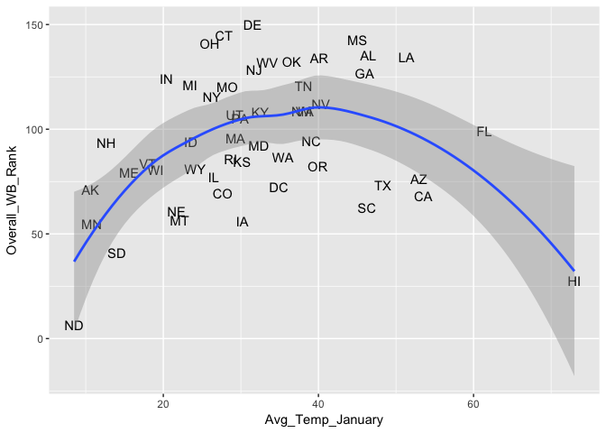

```r
library(ggplot2)


United_Table %>%
  ggplot(aes(x=Avg_Temp_January, y=Overall_WB_Rank, label = State_std)) + geom_text() + geom_smooth()
```

## Much better fit.

As we can see with this updated plot it appears that the best fit for Winter weather vs Overall Well-Being would be a type of polynomial function along the lines of f(x) =-(x^2 - 80 x + 1480). The geom_smooth function automatically defaults to a prediction within a 95% confidence interval for best fit, but as we can see it is a bell-shaped curve somewhat similar to a normal distribution.

#### Some Findings

After finding the curve of best fit for our plot and ruling out a direct linear correlation, we can breakdown some interesting concepts in relation to the topic at hand. Counter-intuitive to my initial thoughts warmer year round weather (as predicted by warmer winter temperatures) do not predict overall happiness and well-being in the United States. According to our best fit curve, it appears that living in weather with more extreme (higher and lower) temperatures actually predict higher rates of well-being across state populations. Obviously, there are many factors with climate that can be also be factored in including rainfall, temperatures throughout other times of year, and proximity to the coast (large bodies of water). Because this is a Intro Data Science tutorial and there are many factors besides temperature to climate we will explore more variables

#### Overall Well-Being Rank Vs. Precipitation by State (Lower Rank is Higher Well Being)

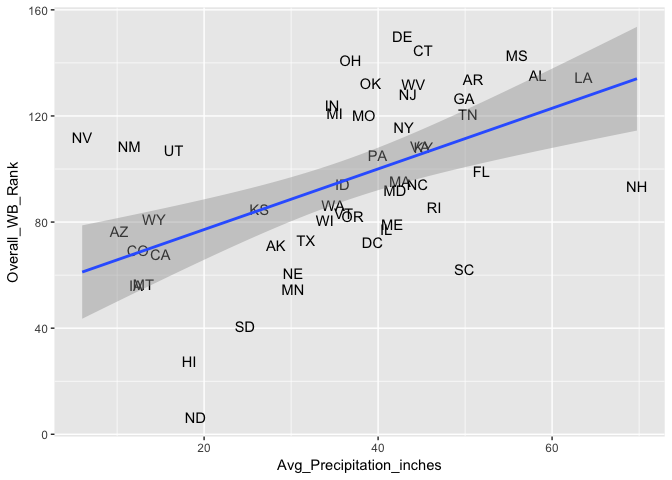

```r
library(ggplot2)


United_Table %>%
  ggplot(aes(x=Avg_Precipitation_inches, y=Overall_WB_Rank, label = State_std)) + geom_text() + geom_smooth(method = lm)
```

#### Statistical analysis and regression model for Precipitation vs. Well Being

```r
library(ggplot2)
library(tidyverse)
library(broom)

# These next to steps are calculating a linear model for average precipitation vs. Overall Well Being.
regr_model <-  lm(United_Table$Avg_Precipitation_inches ~ United_Table$Overall_WB_Rank)
regr_model
```

```
##
## Call:
## lm(formula = United_Table$Avg_Precipitation_inches ~ United_Table$Overall_WB_Rank)
##
## Coefficients:
##                  (Intercept)  United_Table$Overall_WB_Rank
##                      12.7420                        0.2424
```

```r
summary(regr_model)
```

```
##
## Call:
## lm(formula = United_Table$Avg_Precipitation_inches ~ United_Table$Overall_WB_Rank)
##
## Residuals:
##     Min      1Q  Median      3Q     Max
## -33.890  -6.620   1.671   6.744  34.305
##
## Coefficients:
##                              Estimate Std. Error t value Pr(>|t|)
## (Intercept)                  12.74202    5.61466   2.269   0.0277 *
## United_Table$Overall_WB_Rank  0.24244    0.05594   4.334 7.25e-05 ***
## ---
## Signif. codes:  0 '***' 0.001 '**' 0.01 '*' 0.05 '.' 0.1 ' ' 1
##
## Residual standard error: 12.61 on 49 degrees of freedom
## Multiple R-squared:  0.2771, Adjusted R-squared:  0.2624
## F-statistic: 18.78 on 1 and 49 DF,  p-value: 7.252e-05
```

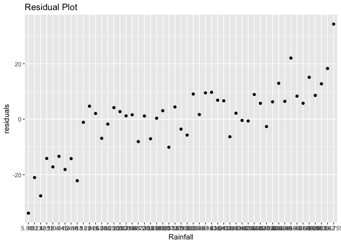

```r
# Create augmented regression model for plotting
augment_regr <- augment(regr_model)

augment_regr %>%
  ggplot(aes(x=factor(United_Table$Avg_Precipitation_inches), y=.resid)) +
    geom_point() +
    labs(title="Residual Plot",
         x = "Rainfall",
         y = "residuals")
```

## Questionable Linear Fit.

So, after running our statistical summary on overall well being vs. precipitation our p-value is much less than the 5% upper bound confidence for a linear fit, but this model only accounts for about 26% of the variation of our fit. Also, after plotting the residuals, it appears that the data is not independent randomly distributed about the line x = 0. It appears that there is a positive linear trend within the residual plot, which may mean that a linear model is not the best fit for our data.

## Climate is complex

After running statistical analyses on two different kinds of trends within our data we can see that basic weather patterns do not necessarily have a quickly interpretable correlation with overall mood and well-being. This is because climate is made up of many variables and so to truly do an in depth breakdown we would most likely need to create a variable that is inclusive of many different weather and location factors that effect climate.